# Correlation (Pearson’s Product Moment Correlation Coefficient)

###### Navigation

- **Intro to R**
- **t-Test** [*t-Test example*]
- **Analysis of Variance (ANOVA)** [*ANOVA example*]
- **Chi Square** [*Chi Square example*]
- **Correlation** [*Correlation example*]
- **Regression** [*Regression example*]

### What is the correlation?

The correlation ($r$) or Pearson’s product-moment correlation coefficient examines the association or relationship between two interval-ratio variables to see if the relationship reflects a true relationship that we could expect to find in the population. The test also tells us the **strength** (weak, moderate, strong) and **direction** (positive, negative) of that relationship. Rarely, we will see a non-relationship or a perfect relationship.

#### Assumptions and Diagnostics for Correlation

The assumptions for the Correlation are…

- Linearity
- Normality
- Absence of Range Restrictions
- Absence of Heterogeneous Subsamples

In addition, the previously-discussed assumptions for other tests (independence of observations) is implied, since all of these bivariate tests require random samples.

```r
library(MASS)
library(psych)
library(lattice)
library(mosaic)
```

```r
data1 <- mtcars
```

##### 1. Linearity

- Variables move together in a linear fashion.
  - Visual inspection of **scatterplot** to see if relationship is linear (straight-line)

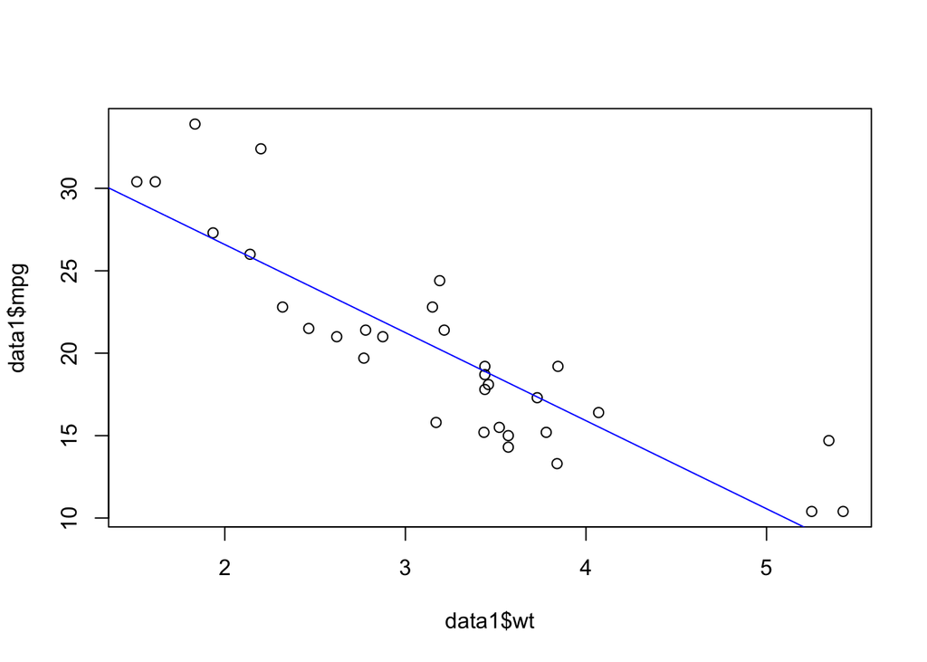

```r
plot(data1$wt, data1$mpg) #(x,y)
abline(lm(data1$mpg~data1$wt), col="Blue") # regression line (y~x))
```

Alternatively, we can add labels to the plot…

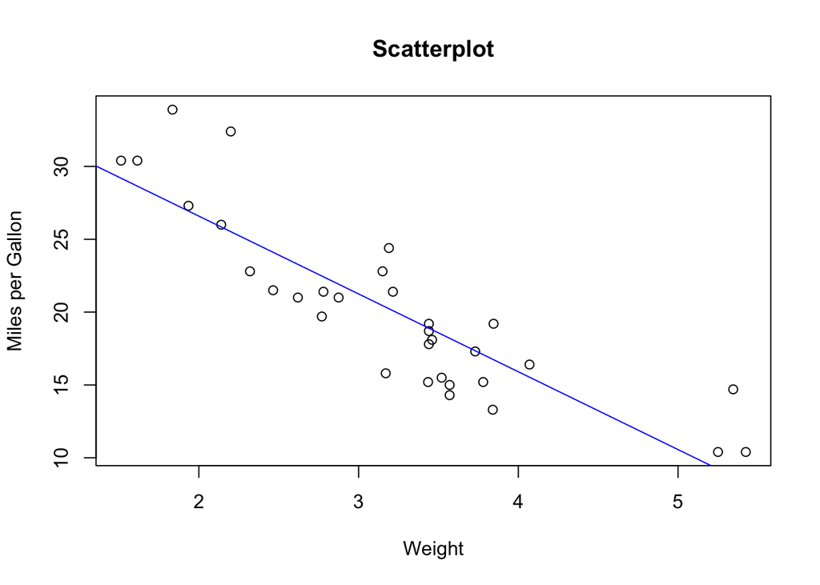

```r
plot(data1$wt, data1$mpg,
     main = "Scatterplot",
     xlab = "Weight",
     ylab = "Miles per Gallon") #(x,y)
abline(lm(data1$mpg~data1$wt), col="Blue") # regression line (y~x))
```

##### 2. Normality

- Distributions must be relatively normal.
  - Visual inspection of…
    - Scatterplot
    - Histograms for each variable
    - Box-and-Whiskers plot for each variable
    - Normality (Q-Q) plot for each variable

##### 2a. Histogram

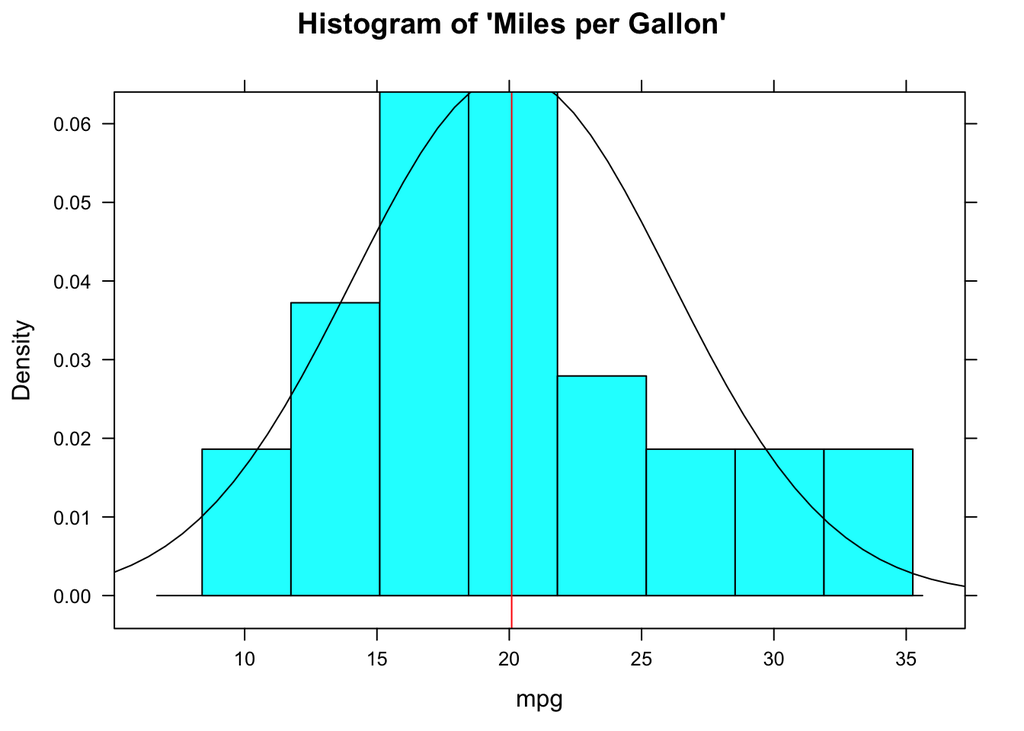

```r
histogram(~ mpg, data = data1, main = "Histogram of 'Miles per Gallon'",
          type = "density",
          panel=function(x, ...) {
            panel.histogram(x, ...)
            panel.abline(v=mean(x, na.rm = TRUE),col="red")
            panel.mathdensity(dmath=dnorm, col="black",
                              args=list(mean=mean(x, na.rm = TRUE),
                                        sd=sd(x, na.rm = TRUE)), ...)
          })
```

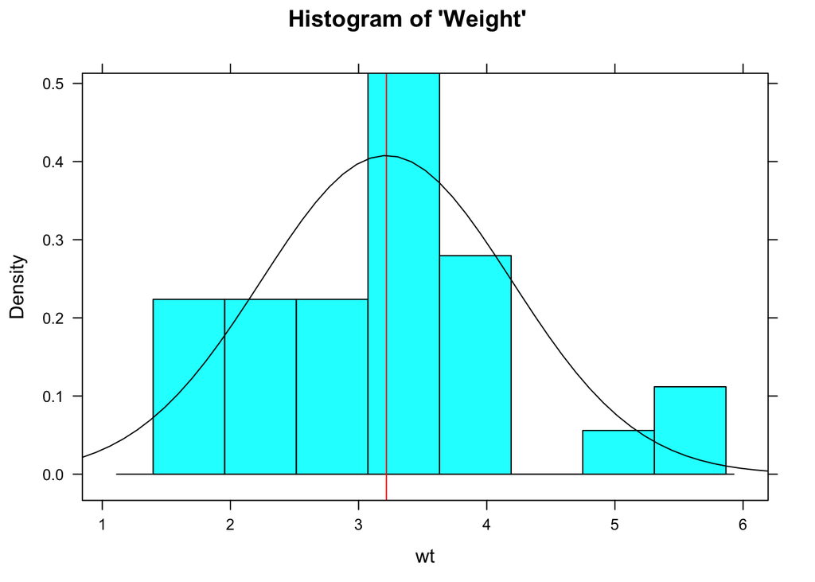

```r
histogram(~ wt, data = data1, main = "Histogram of 'Weight'",
          type = "density",
          panel=function(x, ...) {
            panel.histogram(x, ...)
            panel.abline(v=mean(x, na.rm = TRUE),col="red")
            panel.mathdensity(dmath=dnorm, col="black",
                              args=list(mean=mean(x, na.rm = TRUE),
                                        sd=sd(x, na.rm = TRUE)), ...)
          })
```

##### 2b. Box-and-Whisker Plots

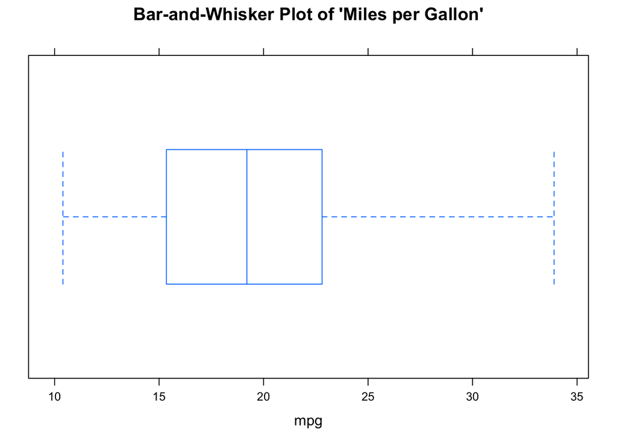

```r
bwplot(~ mpg, data = data1, pch="|", main = "Bar-and-Whisker Plot of 'Miles per Gallon'")
```

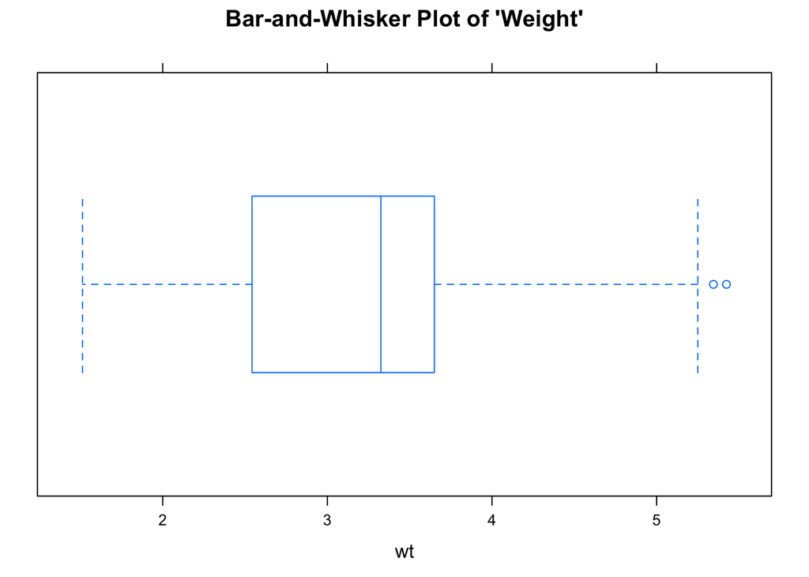

```r
bwplot(~ wt, data = data1, pch="|", main = "Bar-and-Whisker Plot of 'Weight'")
```

##### 2c. Normality (Q-Q) Plots

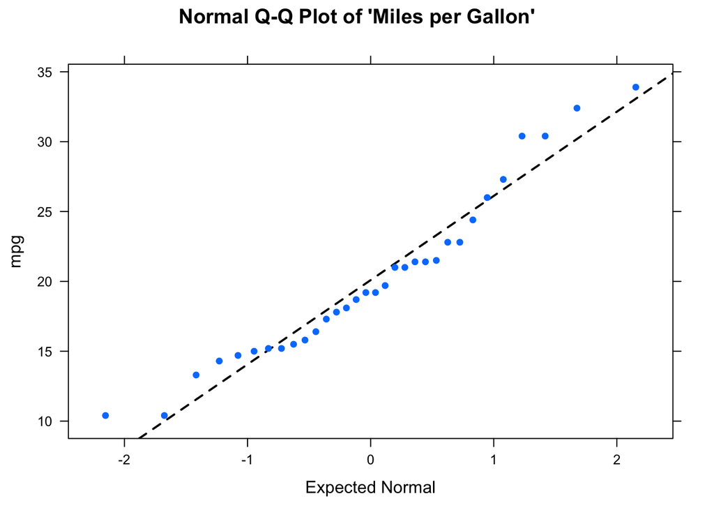

```r
xqqmath(~ mpg, data=data1, fitline = TRUE, main = "Normal Q-Q Plot of 'Miles per Gallon'", xlab = "Expected Normal")
```

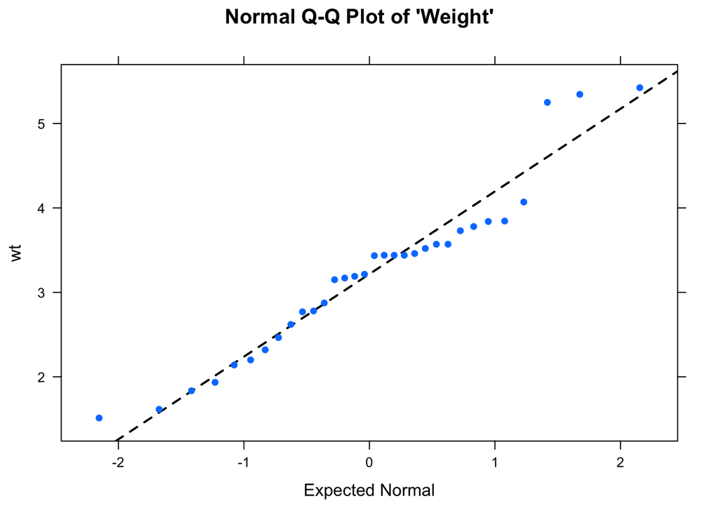

```r
xqqmath(~ wt, data=data1, fitline = TRUE, main = "Normal Q-Q Plot of 'Weight'", xlab = "Expected Normal")
```

##### 3. Absence of Range Restrictions

- Values on variables cannot be restricted to small range
  - Examine range for variables

```r
describe(data1$mpg)
```

```
##    vars  n  mean   sd median trimmed  mad  min  max range skew kurtosis
## X1    1 32 20.09 6.03   19.2    19.7 5.41 10.4 33.9  23.5 0.61    -0.37
##      se
## X1 1.07
```

```r
describe(data1$wt)
```

```
##    vars  n mean   sd median trimmed  mad  min  max range skew kurtosis
## X1    1 32 3.22 0.98   3.33    3.15 0.77 1.51 5.42  3.91 0.42    -0.02
##      se
## X1 0.17
```

##### 4. Absence of Heterogeneous Subsamples

- Not having groups that have extremely different values (e.g. for which a t-test/ANOVA might appropriately identify)
  - Examine various groups in the sample

### The Correlation Test Calculation

The calculation for the correlation is:

$r = \frac{\sum (X - \bar{X})(Y - \bar{Y})}{\sqrt{\sum (X - \bar{X})^2 \sum(Y - \bar{Y})^2}}$

In addition, the degrees of freedom ($df$) for the test is…  
* $df = N - 2$

### Running the Correlation

For Correlation, within the `cor.test` function, the independent variable is listed first and the dependent variable is listed second.

```r
cor.test(data1$wt, data1$mpg)
```

```
##
##  Pearson's product-moment correlation
##
## data:  x and y
## t = -9.559, df = 30, p-value = 1.294e-10
## alternative hypothesis: true correlation is not equal to 0
## 95 percent confidence interval:
##  -0.9338264 -0.7440872
## sample estimates:
##        cor
## -0.8676594
```

In the output above, we see the $r$-obtained value (-.8676594), the degrees of freedom (30), and the p-value (1.294 x $10^{-10}$ = .0000000001294), which is much less than our set alpha level of .05).

To interpret the findings, we report the following information:

- The test used
- If you **reject** or **fail to reject** the null hypothesis
- The variables used in the analysis
- The degrees of freedom, calculated value of the test ($r_{obtained}$), and $p-value$
  - $r(df) = r_{obtained}$, $p-value$

“Using the Pearson’s correlation test ($r$), I reject/fail to reject the null hypothesis that there is no association between variable one and variable 2, in the population, $r(?) = ?, p ? .05$”

“Using the Pearson’s correlation test ($r$), I reject the null hypothesis that there is no association between the weight of a car and its fuel economy in terms of miles per gallon, in the population, $r = -.8676594, p \lt .05$. In particular, we have a *strong* *negative* relationship between car weight and car mpg, such that, as the weight of the car increases, the miles-per-gallon decreases.”